# Predicting classe for Participants doing Weight Lifting Exercises

Divine Miho

May, 2015

## Synopsis

Six young health participants were asked to perform one set of 10 repetitions of the Unilateral Dumbbell Biceps Curl in five different fashions: exactly according to the specification (Class A), throwing the elbows to the front (Class B), lifting the dumbbell only halfway (Class C), lowering the dumbbell only halfway (Class D) and throwing the hips to the front (Class E).

Read more: http://groupware.les.inf.puc-rio.br/har#ixzz3azGt8bfY

My goal is to build a prediction model, using the data collected from gadgets atteched to the participants’ bodies that predicts the classe of 20 observations.

## How I built the model

The training data has 160 variables and 19,622 observations. The first seven variables are not relevant to the analysis. The outcome variable is “classe” which is a factor variable with 5 levels. There are numerous variables with missing data. I remove variables with missing data. The final training dataset has 53 variables. I set the seed to 12345.

## Cross-validation

The exercise provides us with training and testing datasets. For cross-validation I split the training dataset into sub-training(trainTrain) = 75% and sub-testing(trainTest) = 25% datasets. The sub-testing dataset will help me measure the accuracy of the model.

## Choosing the modeling technique

My modeling choice was based on the outcome variable type. The outcome variable is an unordered factor variable. For factor variables tree-based models are better than linear models. I fit two models, one with Recursive Partitioning (rpart) and the other with “Random Forests (rf). The advantages of using tree-based modeling include: easy interpretation, better performance in nonlinear settings and more accuracy in the case of random forests. The disadvatages include: risk of overfitting, hard to meassure uncertainity and poor speeds.

## Analysis

The recursive partioning model has an accuracy of 72.3% while the random forest model has an accuracy of 99.5%. Since the random forest model is more accurate, I will use it as my final model to predict the 20 test observations. The expected out of sample error will be small given the accuracy of the selected model.

## Prediction

1 2 3 4 5 6 7 8 9 10 11 12 13 14 15 16 17 18 19 20

B A B A A E D B A A B C B A E E A B B B

## Code and figures

```r
# Step 1: load packages
library(caret); library(randomForest); library(rattle)
library(lattice); library(ggplot2); library(rpart)
library(rpart.plot); library(RColorBrewer);
library(party); library(partykit);

# step 2: Prepare data
setwd("~/Coursera/Machine_Learning")
trainA <- read.table("pml-training.csv", header = TRUE, sep = ",",
                     na.strings = c("NA","#DIV/0!", ""))
testA <- read.table("pml-testing.csv", header = TRUE, sep = ",",
                    na.strings = c("NA","#DIV/0!", ""))

# remove variables that wont be used in modeling
trainB <- trainA[,-c(1:7)]; testB <- testA[,-c(1:7)]
# Keep columns with complete data
trainC <- trainB[,colSums(is.na(trainB))==0]
testC <- testB[,colSums(is.na(testB))==0]
```

```r
# Data dimensions
trainDim <- rbind(dim(trainA),dim(trainB), dim(trainC))
testDim <- rbind(dim(testA),dim(testB), dim(testC))
cbind(trainDim,testDim)
```

```
##       [,1] [,2] [,3] [,4]
## [1,] 19622  160   20  160
## [2,] 19622  153   20  153
## [3,] 19622   53   20   53
```

```r
# Step 3: explore the response variable
table(trainC$classe)
```

```
##
##    A    B    C    D    E
## 5580 3797 3422 3216 3607
```

```r
# Step 4: Cross validation
set.seed(12345)
inTrain <- createDataPartition(trainC$classe, p = 0.75, list = FALSE)
trainTrain <- trainC[inTrain,]
trainTest <- trainC[-inTrain,]
```

```r
# Step 5: Fit models
# Model 1: rPart model
modFit1 <- rpart(classe ~ ., method = "class", data = trainTrain)
confusionMatrix(trainTest$classe, predict(modFit1,trainTest, type = "class"))
```

```
## Confusion Matrix and Statistics
##
##           Reference
## Prediction    A    B    C    D    E
##          A 1260   52   24   40   19
##          B  156  555  136   33   69
##          C   33   73  575  150   24
##          D   40   52   83  513  116
##          E   23   52   95   89  642
##
## Overall Statistics
##
##                Accuracy : 0.7229
##                  95% CI : (0.7101, 0.7354)
##     No Information Rate : 0.3083
##     P-Value [Acc > NIR] : < 2.2e-16
##
##                   Kappa : 0.6486
##  Mcnemar's Test P-Value : < 2.2e-16
##
## Statistics by Class:
##
##                      Class: A Class: B Class: C Class: D Class: E
## Sensitivity            0.8333   0.7079   0.6298   0.6218   0.7379
## Specificity            0.9602   0.9044   0.9298   0.9287   0.9358
## Pos Pred Value         0.9032   0.5848   0.6725   0.6381   0.7125
## Neg Pred Value         0.9282   0.9421   0.9165   0.9239   0.9430
## Prevalence             0.3083   0.1599   0.1862   0.1682   0.1774
## Detection Rate         0.2569   0.1132   0.1173   0.1046   0.1309
## Detection Prevalence   0.2845   0.1935   0.1743   0.1639   0.1837
## Balanced Accuracy      0.8968   0.8061   0.7798   0.7752   0.8369
```

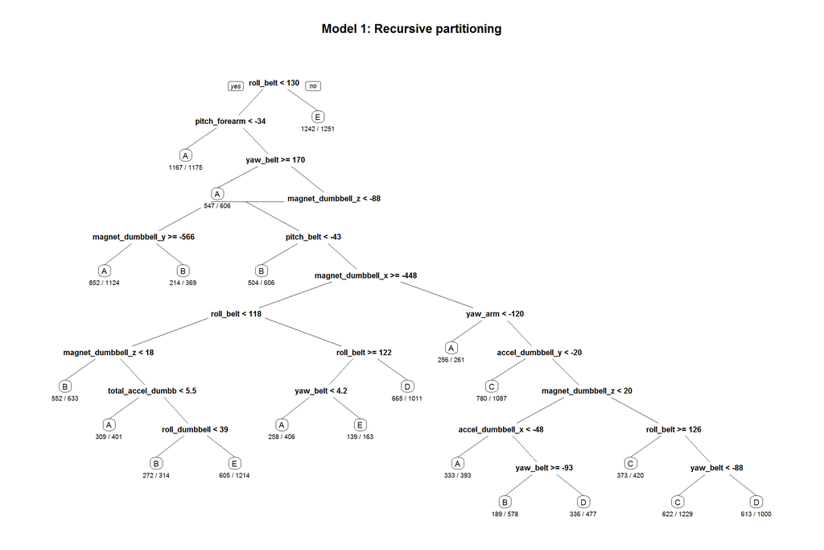

```r
# Plot tree
rpart.plot(modFit1, main="Model 1: Recursive partitioning", type=0,
           extra=2, under=TRUE, faclen=0, cex = 0.7)
```

```r
modFit2 <- randomForest(classe ~ ., data = trainTrain)
confusionMatrix(trainTest$classe, predict(modFit2,trainTest, type = "class"))
```

```
## Confusion Matrix and Statistics
##
##           Reference
## Prediction    A    B    C    D    E
##          A 1395    0    0    0    0
##          B    6  939    4    0    0
##          C    0    2  852    1    0
##          D    0    0    7  797    0
##          E    0    0    1    4  896
##
## Overall Statistics
##
##                Accuracy : 0.9949
##                  95% CI : (0.9925, 0.9967)
##     No Information Rate : 0.2857
##     P-Value [Acc > NIR] : < 2.2e-16
##
##                   Kappa : 0.9936
##  Mcnemar's Test P-Value : NA
##
## Statistics by Class:
##
##                      Class: A Class: B Class: C Class: D Class: E
## Sensitivity            0.9957   0.9979   0.9861   0.9938   1.0000
## Specificity            1.0000   0.9975   0.9993   0.9983   0.9988
## Pos Pred Value         1.0000   0.9895   0.9965   0.9913   0.9945
## Neg Pred Value         0.9983   0.9995   0.9970   0.9988   1.0000
## Prevalence             0.2857   0.1919   0.1762   0.1635   0.1827
## Detection Rate         0.2845   0.1915   0.1737   0.1625   0.1827
## Detection Prevalence   0.2845   0.1935   0.1743   0.1639   0.1837
## Balanced Accuracy      0.9979   0.9977   0.9927   0.9960   0.9994
```

```r
# Out of sample error rate
preds <- predict(modFit2,trainTest, type = "class")
lenPreds <- length(preds)
outSampleError.accu <- sum(preds == trainTest$classe)/lenPreds
outSampleError <- 1 - outSampleError.accu
outSampleError
```

```
## [1] 0.005097879
```

```r
# prediction
predTest <- predict(modFit2, newdata = testA, type = "class")
predTest
```

```
##  1  2  3  4  5  6  7  8  9 10 11 12 13 14 15 16 17 18 19 20
##  B  A  B  A  A  E  D  B  A  A  B  C  B  A  E  E  A  B  B  B
## Levels: A B C D E
```

```r
# Write files for submission
pml_write_files = function(x){
    n = length(x)
    for(i in 1:n){
        filename = paste0("problem_id_",i,".txt")
        write.table(x[i],file=filename,quote=FALSE,row.names=FALSE,col.names=FALSE)
    }
}
pml_write_files(predTest)
```